# PURPOSE OF ANALYSIS

The purpose of this analysis to accurately predict the likelihood of customer taking loan. For the purpose of the this analysis we will look at the target_flag to tranform it into our target variable. The analysis will follow the following pattern :

1.Exploring data using summmary statistics

2.Reducing the # of features by looking at their variance, # of 0 values and categorical variables.

3.Exploring data using visualizations

4.Tranforming the feature using Min-Max Transformation

5.Evaluating SVM , Logistic Regression And Decision Tree

6.Conclusions in light of evaluation metrics ( Accuracy , SSE and Conformance Matrix )

#### IMPORTING LIBRARIES

```python
from pandas import DataFrame, read_csv
import matplotlib.pyplot as plt
import pandas as pd
import numpy as np
import seaborn as sns

file_name = "MNP_Training.xlsx"
sheet_title = "MNP_Training"
df = pd.read_excel(file_name ,  sheet_name =  sheet_title , index_col= False)
```

```python
shape = tuple(df.shape)
print ("Rows in the Dataset - " + str(shape[0]))
print ("Columns in the Dataset - " + str(shape[1]))
```

```
Rows in the Dataset - 19000
Columns in the Dataset - 899
```

```python
new_data = df
target_column = "target_flag"
print("SUMMARY STATISTICS - target_flag \n")
print(new_data.target_flag.describe())
```

```
SUMMARY STATISTICS - target_flag

count    19000.000000
mean         0.424842
std          0.494332
min          0.000000
25%          0.000000
50%          0.000000
75%          1.000000
max          1.000000
Name: target_flag, dtype: float64
```

```python
target_transform = df.target_flag
```

```python
print("Target Flag with value 1        - " + str(target_transform.sum()))
print("Target Flag with value 0 - " + str( 19000 - int(target_transform.sum())) )
```

```
Target Flag with value 1        - 8072
Target Flag with value 0 - 10928
```

### Dropping Target Flag from Data.

```python
new_data = new_data.drop(columns=["target_flag"])
```

### Dropping U_ID from Data

```python
new_data = new_data.drop(columns=["U_ID"])

summary_statistics = new_data.describe()
summary_statistics.loc["Var"] = new_data.var()
summary_statistics.loc["Type"] = new_data.dtypes
summary_statistics = summary_statistics.transpose()
summary_statistics.sort_values(by = "Var").head(10)
```

|  | count | mean | std | min | 25% | 50% | 75% | max | Var | Type |
| --- | --- | --- | --- | --- | --- | --- | --- | --- | --- | --- |
| M3_U_OB_VC_CHINA_CNT_T6 | 19000 | 0 | 0 | 0 | 0 | 0 | 0 | 0 | 0 | int64 |
| M2_U_OB_VC_BAHRAIN_CNT_T6 | 19000 | 0 | 0 | 0 | 0 | 0 | 0 | 0 | 0 | int64 |
| M2_U_OB_VC_BAHRAIN_DUR_T6 | 19000 | 0 | 0 | 0 | 0 | 0 | 0 | 0 | 0 | int64 |
| M2_U_OB_VC_OMAN_CNT_T6 | 19000 | 0 | 0 | 0 | 0 | 0 | 0 | 0 | 0 | int64 |
| M2_U_OB_VC_OMAN_DUR_T6 | 19000 | 0 | 0 | 0 | 0 | 0 | 0 | 0 | 0 | int64 |
| M2_U_OB_VC_KUWAIT_CNT_T6 | 19000 | 0 | 0 | 0 | 0 | 0 | 0 | 0 | 0 | int64 |
| M2_U_OB_VC_KUWAIT_DUR_T6 | 19000 | 0 | 0 | 0 | 0 | 0 | 0 | 0 | 0 | int64 |
| M1_U_OB_FNF_SMS_CNT_T6 | 19000 | 0 | 0 | 0 | 0 | 0 | 0 | 0 | 0 | int64 |
| M1_U_OB_FNF_SMS_REV_T6 | 19000 | 0 | 0 | 0 | 0 | 0 | 0 | 0 | 0 | int64 |
| M2_U_RBT_USSD_REV_T6 | 19000 | 0 | 0 | 0 | 0 | 0 | 0 | 0 | 0 | int64 |

### DIMENSIONALITY REDUCTION

There are 897 features after removing the identifier U_ID and Target variable. All of these features don't contain meaningful information. Therefore, we will remove some of variables which fullfill the following criteria :

Having Variance < 5 = 373 features

```python
columns_to_drop = list( summary_statistics.loc[summary_statistics["Var"] <=5 ].index )
new_data = new_data.drop(columns = columns_to_drop)
print("Numbers of columns having variance < 5 - " + str(len(columns_to_drop) ))

corr_matrix = new_data.corr().abs()
corr_matrix_upper = corr_matrix.where(np.triu(np.ones(corr_matrix.shape), k=1).astype(np.bool))
to_drop = [column for column in corr_matrix_upper.columns if any(corr_matrix_upper[column] > 0.9)]
print("Numbers of columns having correlation > +0.90 - " + str(len(to_drop) ))
new_data = new_data.drop(columns=to_drop)
```

```
Numbers of columns having variance < 5 - 373
Numbers of columns having correlation > +0.90 - 260
```

```python
print("\nFinal Numbers of Features - " + str(len(list(new_data))))

summary_statistics.loc[list(new_data)]
```

```
Final Numbers of Features - 264
```

|  | count | mean | std | min | 25% | 50% | 75% | max | Var | Type |
| --- | --- | --- | --- | --- | --- | --- | --- | --- | --- | --- |
| M1_U_OB_DAY_VC_CC_CNT_T6 | 19000 | 22.0178 | 46.1617 | 0 | 0 | 3 | 21 | 574 | 2130.9 | int64 |
| M1_U_OB_VC_DUR_T6 | 19000 | 194.836 | 523.252 | 0 | 0 | 12 | 141 | 12352 | 273793 | float64 |
| M1_U_OB_VC_REV_T6 | 19000 | 49.5022 | 109.501 | 0 | 0 | 10.157 | 55.0637 | 2203.7 | 11990.4 | float64 |
| M1_U_OB_NGT_VC_CNT_T6 | 19000 | 4.06747 | 12.9211 | 0 | 0 | 0 | 2 | 543 | 166.955 | int64 |
| M1_U_OB_NGT_VC_DUR_T6 | 19000 | 13.8701 | 75.9367 | 0 | 0 | 0 | 3 | 3284 | 5766.39 | float64 |
| M1_U_OB_NGT_VC_REV_T6 | 19000 | 3.73483 | 13.3196 | 0 | 0 | 0 | 2.3 | 758.795 | 177.411 | float64 |
| M1_U_OB_FNF_VC_CNT_T6 | 19000 | 0.677789 | 8.21036 | 0 | 0 | 0 | 0 | 443 | 67.4099 | int64 |
| M1_U_OB_FNF_VC_CC_CNT_T6 | 19000 | 0.291632 | 2.84421 | 0 | 0 | 0 | 0 | 118 | 8.08953 | int64 |
| M1_U_OB_FNF_VC_DUR_T6 | 19000 | 4.21342 | 66.7319 | 0 | 0 | 0 | 0 | 3434 | 4453.15 | float64 |
| M1_U_OB_FNF_VC_REV_T6 | 19000 | 0.451316 | 6.14731 | 0 | 0 | 0 | 0 | 314.888 | 37.7895 | float64 |
| M1_U_OB_ONT_VC_REV_T6 | 19000 | 26.1783 | 54.399 | 0 | 0 | 2.449 | 29.6673 | 1131.44 | 2959.25 | float64 |
| M1_U_OB_OFNT_VC_CC_CNT_T6 | 19000 | 7.32437 | 21.8787 | 0 | 0 | 0 | 5 | 540 | 478.677 | int64 |
| M1_U_OB_OFNT_VC_DUR_T6 | 19000 | 16.9394 | 68.9611 | 0 | 0 | 0 | 8.5 | 2311 | 4755.63 | float64 |
| M1_U_OB_OFNT_VC_REV_T6 | 19000 | 21.4386 | 71.6454 | 0 | 0 | 0 | 13.652 | 1987.5 | 5133.06 | float64 |
| M1_U_OB_OFNT_LND_VC_REV_T6 | 19000 | 0.500514 | 7.1697 | 0 | 0 | 0 | 0 | 545.518 | 51.4046 | float64 |
| M1_U_OB_OFNT_LND_VC_CNT_T6 | 19000 | 0.275211 | 3.30143 | 0 | 0 | 0 | 0 | 319 | 10.8994 | int64 |
| M1_U_OB_OFNT_LND_VC_DUR_T6 | 19000 | 0.583158 | 8.05379 | 0 | 0 | 0 | 0 | 617 | 64.8636 | float64 |
| M1_U_OB_OFNT_MBLNK_VC_CNT_T6 | 19000 | 4.56753 | 17.3208 | 0 | 0 | 0 | 2 | 511 | 300.009 | int64 |
| M1_U_OB_OFNT_MBLNK_VC_DUR_T6 | 19000 | 7.32395 | 36.6135 | 0 | 0 | 0 | 2.5 | 1571 | 1340.55 | float64 |
| M1_U_OB_OFNT_MBLNK_VC_REV_T6 | 19000 | 9.08075 | 37.4595 | 0 | 0 | 0 | 4.451 | 1596.77 | 1403.21 | float64 |
| M1_U_OB_OFNT_UFN_VC_CNT_T6 | 19000 | 2.15911 | 10.3961 | 0 | 0 | 0 | 0 | 490 | 108.079 | int64 |
| M1_U_OB_OFNT_UFN_VC_DUR_T6 | 19000 | 3.75626 | 24.0799 | 0 | 0 | 0 | 0 | 1105 | 579.843 | float64 |
| M1_U_OB_OFNT_UFN_VC_REV_T6 | 19000 | 4.47774 | 24.505 | 0 | 0 | 0 | 0 | 912.238 | 600.494 | float64 |
| M1_U_OB_OFNT_WRD_VC_CNT_T6 | 19000 | 0.972316 | 7.32186 | 0 | 0 | 0 | 0 | 480 | 53.6096 | int64 |
| M1_U_OB_OFNT_WRD_VC_REV_T6 | 19000 | 1.98033 | 14.8244 | 0 | 0 | 0 | 0 | 802.5 | 219.763 | float64 |
| M1_U_OB_OFNT_ZNG_VC_CNT_T6 | 19000 | 2.43932 | 10.223 | 0 | 0 | 0 | 1 | 451 | 104.509 | int64 |
| M1_U_OB_OFNT_ZNG_VC_REV_T6 | 19000 | 5.18835 | 23.9069 | 0 | 0 | 0 | 0 | 614.86 | 571.54 | float64 |
| M1_U_OB_OFNT_INT_VC_DUR_T6 | 19000 | 0.289947 | 5.01546 | 0 | 0 | 0 | 0 | 286 | 25.1548 | float64 |
| M1_U_OB_OFNT_INT_VC_REV_T6 | 19000 | 1.87024 | 25.5758 | 0 | 0 | 0 | 0 | 1680.96 | 654.121 | float64 |
| M1_U_OB_OFNT_NGT_VC_CNT_T6 | 19000 | 0.563684 | 2.50556 | 0 | 0 | 0 | 0 | 86 | 6.27785 | int64 |
| ... | ... | ... | ... | ... | ... | ... | ... | ... | ... | ... |
| M3_RECH_250_300_AMT | 19000 | 2.69064 | 33.1724 | 0 | 0 | 0 | 0 | 1000 | 1100.41 | float64 |
| M3_RECH_300_500_AMT | 19000 | 11.8365 | 75.1966 | 0 | 0 | 0 | 0 | 1600 | 5654.53 | int64 |
| M3_RECH_500_750_AMT | 19000 | 6.03953 | 71.9135 | 0 | 0 | 0 | 0 | 4000 | 5171.56 | int64 |
| M3_RECH_750_1000_AMT | 19000 | 0.434472 | 18.9973 | 0 | 0 | 0 | 0 | 950 | 360.896 | float64 |
| M3_RECH_GT_1000_AMT | 19000 | 6.27021 | 144.289 | 0 | 0 | 0 | 0 | 10602 | 20819.3 | int64 |
| M3_SMARTSHARE_AMT | 19000 | 0.552324 | 9.24417 | 0 | 0 | 0 | 0 | 590.23 | 85.4547 | float64 |
| M3_LOAN_AMT | 19000 | 18.6355 | 38.741 | 0 | 0 | 0 | 15 | 570 | 1500.86 | int64 |
| M3_EC350_RECH_AMT | 19000 | 8.91579 | 62.2848 | 0 | 0 | 0 | 0 | 1400 | 3879.4 | int64 |
| M3_EC600_RECH_AMT | 19000 | 1.98947 | 35.575 | 0 | 0 | 0 | 0 | 1200 | 1265.58 | int64 |
| M3_EL_170_RECH_AMT | 19000 | 0.662105 | 17.1657 | 0 | 0 | 0 | 0 | 680 | 294.661 | int64 |
| M1_OG_CALLS | 19000 | 188.767 | 364.558 | 0 | 3 | 49 | 214 | 14590 | 132902 | int64 |
| M1_OG_FAILURES | 19000 | 6.89132 | 23.4881 | 0 | 0 | 1 | 6 | 1635 | 551.689 | int64 |
| M1_OCQ | 19000 | 77.412 | 38.6216 | 0 | 87.5 | 97.1 | 100 | 200 | 1491.63 | float64 |
| M2_OG_CALLS | 19000 | 167.399 | 328.999 | 0 | 0 | 35 | 186 | 8427 | 108240 | int64 |
| M2_OG_FAILURES | 19000 | 5.90795 | 21.589 | 0 | 0 | 0 | 5 | 1152 | 466.084 | int64 |
| M2_OCQ | 19000 | 69.5925 | 43.8283 | 0 | 0 | 96.7 | 99.5 | 198 | 1920.92 | float64 |
| M2_CST | 19000 | 3.20692 | 2.37287 | 0 | 0 | 3.78 | 5.21 | 22.59 | 5.63053 | float64 |
| M3_OG_CALLS | 19000 | 144.587 | 302.512 | 0 | 0 | 22 | 154 | 5377 | 91513.2 | int64 |
| M3_OG_FAILURES | 19000 | 5.41774 | 23.8153 | 0 | 0 | 0 | 4 | 2030 | 567.169 | int64 |
| M3_OCQ | 19000 | 65.2547 | 45.6328 | 0 | 0 | 96.2 | 99.5 | 200 | 2082.35 | float64 |
| M3_CST | 19000 | 3.00823 | 2.42358 | 0 | 0 | 3.42 | 5.15 | 14.93 | 5.87376 | float64 |
| M1_ARPU | 19000 | 59.8811 | 214.06 | 0 | 0 | 0 | 7.23465 | 4409.33 | 45821.7 | float64 |
| M1_GPRS_REV | 19000 | 8.72038 | 38.4456 | 0 | 0 | 0 | 0.052775 | 2032.29 | 1478.06 | float64 |
| M1_GPRS_VOL | 19000 | 611588 | 2.55272e+06 | 0 | 0 | 0 | 3819 | 8.99962e+07 | 6.51636e+12 | int64 |
| M2_ARPU | 19000 | 58.1483 | 233.739 | 0 | 0 | 0 | 0 | 5341.74 | 54633.8 | float64 |
| M2_GPRS_REV | 19000 | 6.88532 | 34.2992 | 0 | 0 | 0 | 0 | 2311.97 | 1176.43 | float64 |
| M2_GPRS_VOL | 19000 | 583871 | 2.46374e+06 | 0 | 0 | 0 | 576 | 8.28538e+07 | 6.07002e+12 | int64 |
| M3_ARPU | 19000 | 56.4232 | 230.691 | 0 | 0 | 0 | 0 | 4733.53 | 53218.3 | float64 |
| M3_GPRS_REV | 19000 | 6.71406 | 38.2885 | 0 | 0 | 0 | 0 | 2281.22 | 1466.01 | float64 |
| M3_GPRS_VOL | 19000 | 562154 | 2.39461e+06 | 0 | 0 | 0 | 124.25 | 9.91186e+07 | 5.73415e+12 | int64 |

264 rows × 10 columns

### FINAL FEATURE SET

Based on the features removal techniques, we now have a total of 264 variables.

And there are no missing values.

```python
from sklearn.preprocessing import MinMaxScaler
scaler = MinMaxScaler()
col_names = list(new_data.columns)
new_data[col_names] = scaler.fit_transform(new_data[col_names])
print("\nImputed and MIX Max Tranformation Variable Summary")
new_data.describe().transpose().head(10)
```

```
Imputed and MIX Max Tranformation Variable Summary
```

|  | count | mean | std | min | 25% | 50% | 75% | max |
| --- | --- | --- | --- | --- | --- | --- | --- | --- |
| M1_U_OB_DAY_VC_CC_CNT_T6 | 19000.0 | 0.038359 | 0.080421 | 0.0 | 0.0 | 0.005226 | 0.036585 | 1.0 |
| M1_U_OB_VC_DUR_T6 | 19000.0 | 0.015774 | 0.042362 | 0.0 | 0.0 | 0.000972 | 0.011415 | 1.0 |
| M1_U_OB_VC_REV_T6 | 19000.0 | 0.022463 | 0.049689 | 0.0 | 0.0 | 0.004609 | 0.024987 | 1.0 |
| M1_U_OB_NGT_VC_CNT_T6 | 19000.0 | 0.007491 | 0.023796 | 0.0 | 0.0 | 0.000000 | 0.003683 | 1.0 |
| M1_U_OB_NGT_VC_DUR_T6 | 19000.0 | 0.004224 | 0.023123 | 0.0 | 0.0 | 0.000000 | 0.000914 | 1.0 |
| M1_U_OB_NGT_VC_REV_T6 | 19000.0 | 0.004922 | 0.017554 | 0.0 | 0.0 | 0.000000 | 0.003031 | 1.0 |
| M1_U_OB_FNF_VC_CNT_T6 | 19000.0 | 0.001530 | 0.018534 | 0.0 | 0.0 | 0.000000 | 0.000000 | 1.0 |
| M1_U_OB_FNF_VC_CC_CNT_T6 | 19000.0 | 0.002471 | 0.024103 | 0.0 | 0.0 | 0.000000 | 0.000000 | 1.0 |
| M1_U_OB_FNF_VC_DUR_T6 | 19000.0 | 0.001227 | 0.019433 | 0.0 | 0.0 | 0.000000 | 0.000000 | 1.0 |
| M1_U_OB_FNF_VC_REV_T6 | 19000.0 | 0.001433 | 0.019522 | 0.0 | 0.0 | 0.000000 | 0.000000 | 1.0 |

### Visual Implimentations:

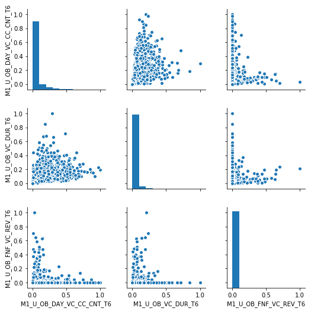

```python
variables_of_interest = [ 'M1_U_OB_DAY_VC_CC_CNT_T6','M1_U_OB_VC_DUR_T6','M1_U_OB_FNF_VC_REV_T6']
sns.pairplot(new_data[variables_of_interest])
```

```python
greater_percent = 100.0 * target_transform.sum() / 19000
accuracy = greater_percent / 100.0

# TODO: Calculate F-score using the formula above for beta = 0.5
beta = 0.5
recall = 1.0
fscore = (1 + beta**2) * accuracy * recall / (beta**2 * accuracy + recall)

# Print the results
print("Naive predictor: [Accuracy score: {:.4f}, F-score: {:.4f}]".format(accuracy, fscore))
```

```
Naive predictor: [Accuracy score: 0.4248, F-score: 0.4801]
```

### SPLITTING THE DATASET

```python
from sklearn.cross_validation import train_test_split
X_train, X_test, y_train, y_test = train_test_split(new_data, target_transform, test_size = 0.3, random_state = 0)
print("Train set has {} samples.".format(X_train.shape[0]))
print("Testing set has {} samples.".format(X_test.shape[0]))
```

```
Train set has 13300 samples.
Testing set has 5700 samples.
```

# MODEL FITTING

Therfoer ,the goal is the identify a model which has a prediction accuracy of greater than 76% . For this purpose we will be fitting the training dataset on the following models :

Logistic Regression

LinearSVC

Decision Tree

```
Fitting - Logistic Regression Model

Test Data - Accuracy
0.8773684210526316

Test Data - Confusion Matrix
[[2956  315]
 [ 384 2045]]

Test Data - SSE Matrix
0.12263157894736842

Test Data - FScore
0.8614879096806807

 ROC Curve
```

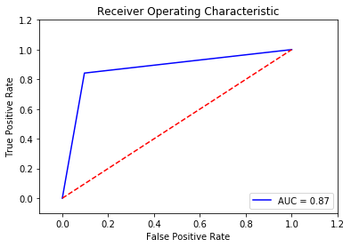

```
Fitting - Linear SVC Model

Test Data - Accuracy
0.9310526315789474

Test Data - Confusion Matrix
[[3041  230]
 [ 163 2266]]

Test Data - SSE Matrix
0.06894736842105263

Test Data - FScore
0.9127527592040603

 ROC Curve
```

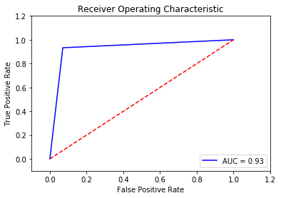

```
Fitting - Decision Tree Model

Test Data - Accuracy
0.9978947368421053

Test Data - Confusion Matrix
[[3260   11]
 [   1 2428]]

Test Data - SSE Matrix
0.002105263157894737

Test Data - FScore
0.9963069347558474

 ROC Curve
```

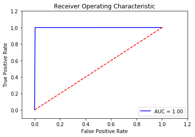

```python
from sklearn.linear_model import LogisticRegression, SGDClassifier
from sklearn.svm import LinearSVC, SVC
from sklearn.tree import DecisionTreeClassifier
from sklearn import metrics
from sklearn.metrics import mean_squared_error
from sklearn.metrics import roc_curve, auc
from sklearn.metrics import fbeta_score
from sklearn.ensemble import AdaBoostClassifier, GradientBoostingClassifier
from sklearn.naive_bayes import GaussianNB

import matplotlib.pyplot as plt

clf_A = LogisticRegression(random_state=101)
clf_B = LinearSVC(random_state=101)
clf_C = DecisionTreeClassifier(random_state = 101)

print("\n\nFitting - Logistic Regression Model")
clf_A.fit(X_train,y_train)
print("\nTest Data - Accuracy")
print(clf_A.score(X_test, y_test))
print("\nTest Data - Confusion Matrix")
print(metrics.confusion_matrix(y_test, clf_A.predict(X_test)))
print("\nTest Data - SSE Matrix")
print(mean_squared_error(y_test, clf_A.predict(X_test)))
print("\nTest Data - FScore")
predictions_test = clf_A.predict(X_test)
print(fbeta_score(y_test, predictions_test, beta=beta))

print("\n ROC Curve")
false_positive_rate, true_positive_rate, thresholds = roc_curve(y_test, clf_A.predict(X_test))
roc_auc = auc(false_positive_rate, true_positive_rate)
plt.title('Receiver Operating Characteristic')
plt.plot(false_positive_rate, true_positive_rate, 'b',
label='AUC = %0.2f'% roc_auc)
plt.legend(loc='lower right')
plt.plot([0,1],[0,1],'r--')
plt.xlim([-0.1,1.2])
plt.ylim([-0.1,1.2])
plt.ylabel('True Positive Rate')
plt.xlabel('False Positive Rate')
plt.show()

print("\n\nFitting - Linear SVC Model")
clf_B.fit(X_train,y_train)
print("\nTest Data - Accuracy")
print(clf_B.score(X_test, y_test))
print("\nTest Data - Confusion Matrix")
print(metrics.confusion_matrix(y_test, clf_B.predict(X_test)))
print("\nTest Data - SSE Matrix")
print(mean_squared_error(y_test, clf_B.predict(X_test)))
print("\nTest Data - FScore")
predictions_test = clf_B.predict(X_test)
print(fbeta_score(y_test, predictions_test, beta=beta))

print("\n ROC Curve")
false_positive_rate, true_positive_rate, thresholds = roc_curve(y_test, clf_B.predict(X_test))
roc_auc = auc(false_positive_rate, true_positive_rate)
plt.title('Receiver Operating Characteristic')
plt.plot(false_positive_rate, true_positive_rate, 'b',
label='AUC = %0.2f'% roc_auc)
plt.legend(loc='lower right')
plt.plot([0,1],[0,1],'r--')
plt.xlim([-0.1,1.2])
plt.ylim([-0.1,1.2])
plt.ylabel('True Positive Rate')
plt.xlabel('False Positive Rate')
plt.show()

print("\n\nFitting - Decision Tree Model")
clf_C.fit(X_train,y_train)
print("\nTest Data - Accuracy")
print(clf_C.score(X_test, y_test))
print("\nTest Data - Confusion Matrix")
print(metrics.confusion_matrix(y_test, clf_C.predict(X_test)))
print("\nTest Data - SSE Matrix")
print(mean_squared_error(y_test, clf_C.predict(X_test)))
print("\nTest Data - FScore")
predictions_test = clf_C.predict(X_test)
print(fbeta_score(y_test, predictions_test, beta=beta))

print("\n ROC Curve")
false_positive_rate, true_positive_rate, thresholds = roc_curve(y_test, clf_C.predict(X_test))
roc_auc = auc(false_positive_rate, true_positive_rate)
plt.title('Receiver Operating Characteristic')
plt.plot(false_positive_rate, true_positive_rate, 'b',
label='AUC = %0.2f'% roc_auc)
plt.legend(loc='lower right')
plt.plot([0,1],[0,1],'r--')
plt.xlim([-0.1,1.2])
plt.ylim([-0.1,1.2])
plt.ylabel('True Positive Rate')
plt.xlabel('False Positive Rate')
plt.show()


import pickle
filename = 'finalized_model.sav'
pickle.dump(model, open(filename, 'wb'))
```

### Results:

| Metric | Logistic Regression | Linear SVC | Decision Tree |
| --- | --- | --- | --- |
| Accuracy Score | 0.8773 | 0.9310 | 0.9978 |
| F-score | 0.8614 | 0.9127 | 0.9963 |

### Decision Tree Model is the Best Model

### Implementation: Model Tuning

Fine tune the chosen model. Use grid search (`GridSearchCV`) with at least one important parameter tuned with at least 3 different values. You will need to use the entire training set for this.

As there is Accuracy Score of almost 1 for decision tree, so we choose logistic regression for model tuning.

```python
# TODO: Import 'GridSearchCV', 'make_scorer', and any other necessary libraries
from sklearn.grid_search import GridSearchCV
from sklearn.metrics import make_scorer

# TODO: Initialize the classifier
clf = LogisticRegression(random_state=101)

# TODO: Create the parameters list you wish to tune
parameters = {'solver': ['newton-cg', 'lbfgs', 'sag'],
              'C': [0.01, 0.1, 1.0, 10.0, 100.0]
             }

# TODO: Make an fbeta_score scoring object
scorer = make_scorer(fbeta_score, beta=beta)

# TODO: Perform grid search on the classifier using 'scorer' as the scoring method
grid_obj = GridSearchCV(clf, parameters, scoring=scorer)

# TODO: Fit the grid search object to the training data and find the optimal parameters
grid_fit = grid_obj.fit(X_train, y_train)

# Get the estimator
best_clf = grid_fit.best_estimator_

# Make predictions using the unoptimized and model
predictions = (clf.fit(X_train, y_train)).predict(X_test)
best_predictions = best_clf.predict(X_test)
# Report the before-and-afterscores
print ("Unoptimized model\n------")
print ("Accuracy score on testing data: {:.4f}".format(accuracy_score(y_test, predictions)))
print ("F-score on testing data: {:.4f}".format(fbeta_score(y_test, predictions, beta = 0.5)))
print ("\nOptimized Model\n------")
print ("Final accuracy score on the testing data: {:.4f}".format(accuracy_score(y_test, best_predictions)))
print ("Final F-score on the testing data: {:.4f}".format(fbeta_score(y_test, best_predictions, beta = 0.5)))

# show best parameters
print ("\nBest Classifier\n------")
print (best_clf)
```

```
Unoptimized model
------
Accuracy score on testing data: 0.8774
F-score on testing data: 0.8615

Optimized Model
------
Final accuracy score on the testing data: 0.9642
Final F-score on the testing data: 0.9472

Best Classifier
------
LogisticRegression(C=100.0, class_weight=None, dual=False, fit_intercept=True,
          intercept_scaling=1, max_iter=100, multi_class='ovr', n_jobs=1,
          penalty='l2', random_state=101, solver='newton-cg', tol=0.0001,
          verbose=0, warm_start=False)
```

#### Results:

| Metric | Benchmark Predictor | Unoptimized Model | Optimized Model |
| --- | --- | --- | --- |
| Accuracy Score | 0.4248 | 0.8774 | 0.9642 |
| F-score | 0.4801 | 0.8615 | 0.9472 |

### CLASSIFICATION

```python
# TODO: Import a supervised learning model that has 'feature_importances_'
from sklearn.ensemble import AdaBoostClassifier, RandomForestClassifier, GradientBoostingClassifier
from sklearn.metrics import fbeta_score, accuracy_score

# TODO: Train the supervised model on the training set
clf_a = GradientBoostingClassifier().fit(X_train, y_train)
clf_b = AdaBoostClassifier().fit(X_train, y_train)
clf_c = RandomForestClassifier().fit(X_train, y_train)


# show scores
predictions = clf_a.predict(X_test)
model_accuracy = accuracy_score(y_test, predictions)
model_fscore = fbeta_score(y_test, predictions, beta=0.5)
print ("\nGradient Boosting Model accuracy:", model_accuracy, ", fscore: ", model_fscore)

predictions = clf_b.predict(X_test)
model_accuracy = accuracy_score(y_test, predictions)
model_fscore = fbeta_score(y_test, predictions, beta=0.5)
print ("\nAdaptive Boosting Model accuracy:", model_accuracy, ", fscore: ", model_fscore)

predictions = clf_c.predict(X_test)
model_accuracy = accuracy_score(y_test, predictions)
model_fscore = fbeta_score(y_test, predictions, beta=0.5)
print ("\nRandom Forest Model accuracy:", model_accuracy, ", fscore: ", model_fscore)
```

```
Gradient Boosting Model accuracy: 0.9973684210526316 , fscore:  0.9953267196851684

Adaptive Boosting Model accuracy: 0.9980701754385964 , fscore:  0.996390187874313

Random Forest Model accuracy: 0.9963157894736843 , fscore:  0.9955551897275496
```

```python
clf_b = AdaBoostClassifier(n_estimators=500,random_state=10).fit(X_train, y_train)

predictions = clf_b.predict(X_test)
model_accuracy = accuracy_score(y_test, predictions)
model_fscore = fbeta_score(y_test, predictions, beta=0.5)
print ("\nAdaptive Boosting Model accuracy:", model_accuracy, ", fscore: ", model_fscore)
```

```
Adaptive Boosting Model accuracy: 0.9982456140350877 , fscore:  0.996717275338531
```

This accuracy is more closer to 1 and we take it as the best boosting model.

### Implementation - Extracting Feature Importance

Choose a scikit-learn supervised learning algorithm that has a feature*importance* attribute availble for it. This attribute is a function that ranks the importance of each feature when making predictions based on the chosen algorithm.

So we are extracting Feature importance from the Decision Tree Model.

```python
DecisionTreeModel = clf_C

# TODO: Extract the feature importances
importances = DecisionTreeModel.feature_importances_

# show most importance features
a = np.array(importances)
factors = pd.DataFrame(data = np.array([importances.astype(float), new_data.columns]).T,
                       columns = ['importances', 'features'])
factors = factors.sort_values('importances', ascending=False)

print ("\n Top 10 important features")
display(factors[:10])
```

```
 Top 10 important features
```

|  | importances | features |
| --- | --- | --- |
| 255 | 0.564015 | M1_ARPU |
| 244 | 0.336369 | M1_OG_CALLS |
| 251 | 0.0561024 | M3_OG_CALLS |
| 257 | 0.0179411 | M1_GPRS_VOL |
| 184 | 0.01146 | M1_RECH_AMT |
| 247 | 0.00607037 | M2_OG_CALLS |
| 61 | 0.00442275 | M1_U_VAS_REV_T6 |
| 204 | 0.000893415 | M2_RECH_AMT |
| 225 | 0.00059727 | M3_RECH_CNT |
| 261 | 0.000310502 | M3_ARPU |

## Scoring from scoring data

```python
from pandas import DataFrame, read_csv
import matplotlib.pyplot as plt
import pandas as pd
import numpy as np
import seaborn as sns

file_name = "MNP_Scoring.xlsx"
sheet_title = "MNP_Scoring"
df1 = pd.read_excel(file_name ,  sheet_name =  sheet_title , index_col= False)
```

```python
new_data1 = df1.drop(columns=["U_ID"])
```

```python
summary_statistics1 = new_data1.describe()
summary_statistics1.loc["Var"] = new_data1.var()
summary_statistics1.loc["Type"] = new_data1.dtypes
summary_statistics1 = summary_statistics1.transpose()
summary_statistics1.sort_values(by ="Var").head(10)
```

|  | count | mean | std | min | 25% | 50% | 75% | max | Var | Type |
| --- | --- | --- | --- | --- | --- | --- | --- | --- | --- | --- |
| M1_U_OB_VC_France_DUR_T6 | 2000 | 0 | 0 | 0 | 0 | 0 | 0 | 0 | 0 | int64 |
| M1_U_OB_HYBD_INT_VC_DUR_T6 | 2000 | 0 | 0 | 0 | 0 | 0 | 0 | 0 | 0 | int64 |
| M1_U_OB_VC_Germany_DUR_T6 | 2000 | 0 | 0 | 0 | 0 | 0 | 0 | 0 | 0 | int64 |
| M2_U_VAS_CC_SMS_CNT_T6 | 2000 | 0 | 0 | 0 | 0 | 0 | 0 | 0 | 0 | int64 |
| M1_U_VAS_PHNBOOK_SVC_REV_T6 | 2000 | 0 | 0 | 0 | 0 | 0 | 0 | 0 | 0 | int64 |
| M1_U_OB_VC_France_CNT_T6 | 2000 | 0 | 0 | 0 | 0 | 0 | 0 | 0 | 0 | int64 |
| M1_U_VAS_PHNBOOK_SVC_CNT_T6 | 2000 | 0 | 0 | 0 | 0 | 0 | 0 | 0 | 0 | int64 |
| M1_U_VAS_NEWS_RADIO_CNT_T6 | 2000 | 0 | 0 | 0 | 0 | 0 | 0 | 0 | 0 | int64 |
| M1_U_OB_VC_Norway_DUR_T6 | 2000 | 0 | 0 | 0 | 0 | 0 | 0 | 0 | 0 | int64 |
| M3_U_OB_VC_Denmark_CNT_T6 | 2000 | 0 | 0 | 0 | 0 | 0 | 0 | 0 | 0 | int64 |

```python
columns_to_drop1 = list( summary_statistics1.loc[summary_statistics1["Var"] <=3.5 ].index )
print("Numbers of columns having variance < 3.5 - " + str(len(columns_to_drop1) ))
new_data1 = new_data1.drop(columns = columns_to_drop1)

corr_matrix1 = new_data1.corr().abs()
corr_matrix_upper1 = corr_matrix1.where(np.triu(np.ones(corr_matrix1.shape), k=1).astype(np.bool))
to_drop1 = [column for column in corr_matrix_upper1.columns if any(corr_matrix_upper1[column] > 0.9385)]
print("Numbers of columns having correlation > +0.9385 - " + str(len(to_drop1) ))
new_data1 = new_data1.drop(columns=to_drop1)

print("\nFinal Numbers of Features - " + str(len(list(new_data1))))
```

[output not shown]

```python
import pickle

filename_model = 'finalized_model.sav'

loaded_model = pickle.load(open(filename_model, 'rb'))

target1 = target_transform[0:2000]

from sklearn.cross_validation import train_test_split
X_train1, X_test1, y_train1, y_test1 = train_test_split(new_data1, target1, test_size = 0.1, random_state = 0)
print("Training set has {} samples.".format(X_train1.shape[0]))
print("Testing set has {} samples.".format(X_test1.shape[0]))
```

```
Training set has 1800 samples.
Testing set has 200 samples.
```

```python
result1 = loaded_model.score(X_train1, y_train1)
result2 = loaded_model.score(X_test1, y_test1)
```

```python
result = result1 + result2
print("Score =",result)
```

```
Score = 0.9477777777777778
```

```python
prediction1 = loaded_model.predict(X_train1)
```

```python
print(prediction1)
```

```
[1 1 1 ... 1 0 1]
```

```python
print("Outcome")
print("-------")
for i,each in enumerate(prediction1,start=1):
    print ("{}. {}".format(i,each))
```

[output not shown]

[output cut: 1747 more lines]

[output not shown]

```python
print("value 1 - " + str(prediction1.sum()))
print("value 0 - " + str( 1800 - int(prediction1.sum())) )
```

```
value 1 - 1485
value 0 - 315
```